# Презентация по пятому этапу индивидуального пректа

Burb Suite

Барето Вилиан Мануел

Российский университет дружбы народов, Москва, Россия

16 мая 2025

# Информация

## Докладчик

- Барето Вилиан Мануел
- НКАбд 03-24
- Факультет физико-математических и естесвенных наук
- Российский университет дружбы народов
- 1032239248@rudn.ru

# Цель работы

Научиться использовть Burp Suite.

# Выполнение лабораторной работы

## Запуск сервера

Запускаю локальный серевер DVWA:

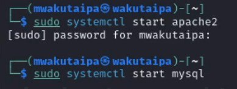

Запуск сервера

## Запуск Burp suite

Запускаю burp suite:

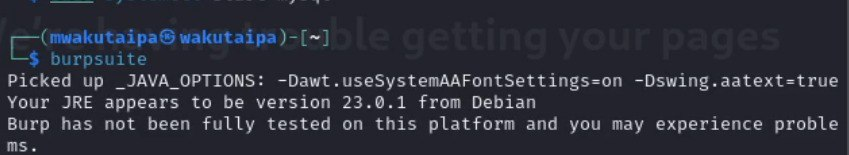

Запуск Burp suite

## сетевые настройки сервера

Открываю сетевые настройки браузера и изменяю настройки сервера для работы с proxy и захватом данных с burp suite:

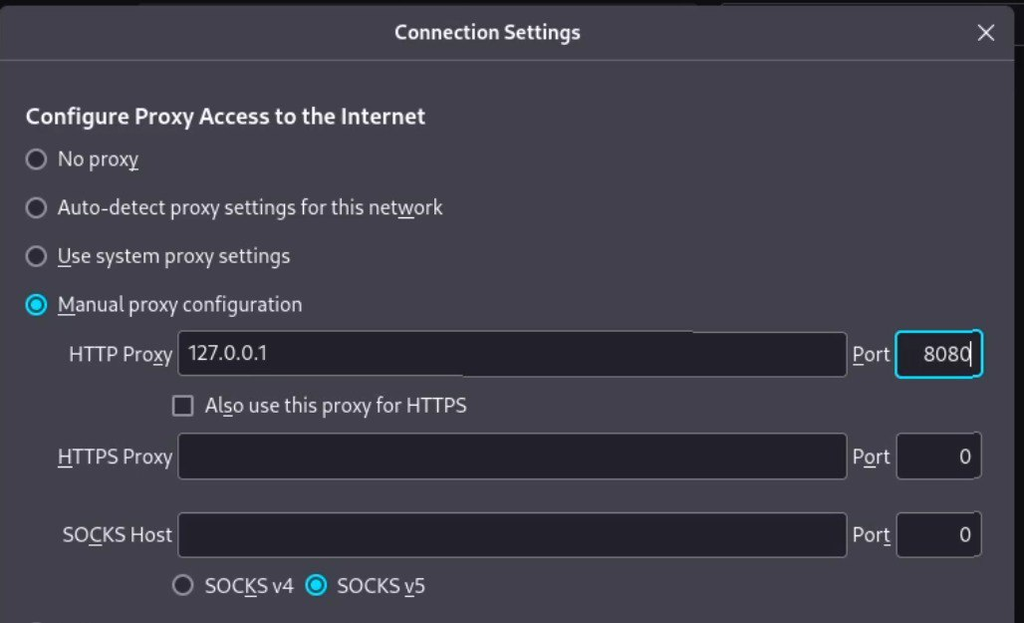

сетевые настройки сервера

## настройки proxy

Изменяю настройки proxy инструмента burp suite:

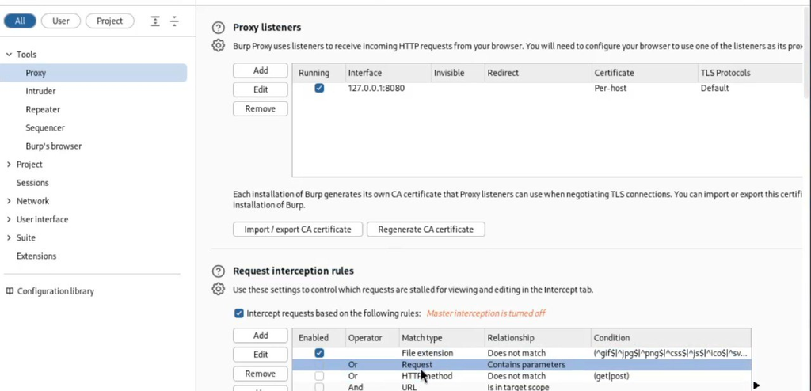

настройки proxy

## Включение intercept

Включаю intercept во вкладе proxy:

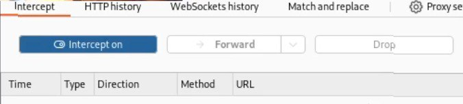

Включение intercept

## Установка параметра локального хоста

Необходимо установить параметр network_allow_hijacking_localhost на true ,чтобы burp suite работал с локальным сервером. Я это и делала:

[figure not shown]

Установка параметра локального хоста

## Пытка зайти в dvwa

Пытаюсь зайти на dvwa в браузаре и во вкладки proxy появляется запрос. Нажимаю forward, чтобы загрузить страницу:

[figure not shown]

Пытка зайти в dvwa

## вкладка proxy

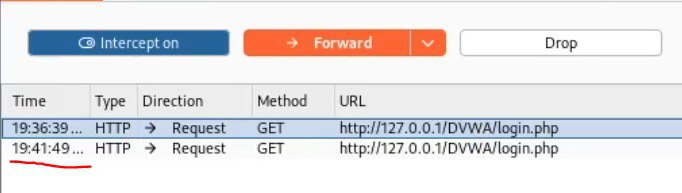

вкладка proxy

## окно dvwa

[figure not shown]

окно dvwa

## Измененные данные

Когда пытаюсь ввести неправильные логин и пароль, в запросе появляется строка, в которой отображается введенные данные. Этот же запрос ,во вкладке target, отправила к злоумышленнику (send to intruder). Во вкладке intruder, изменяю тип атаки (на cluster bomb) и данные для входа.

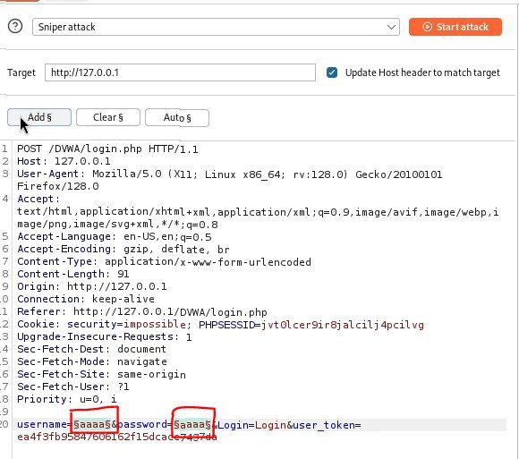

Измененные данные

## Тип атака

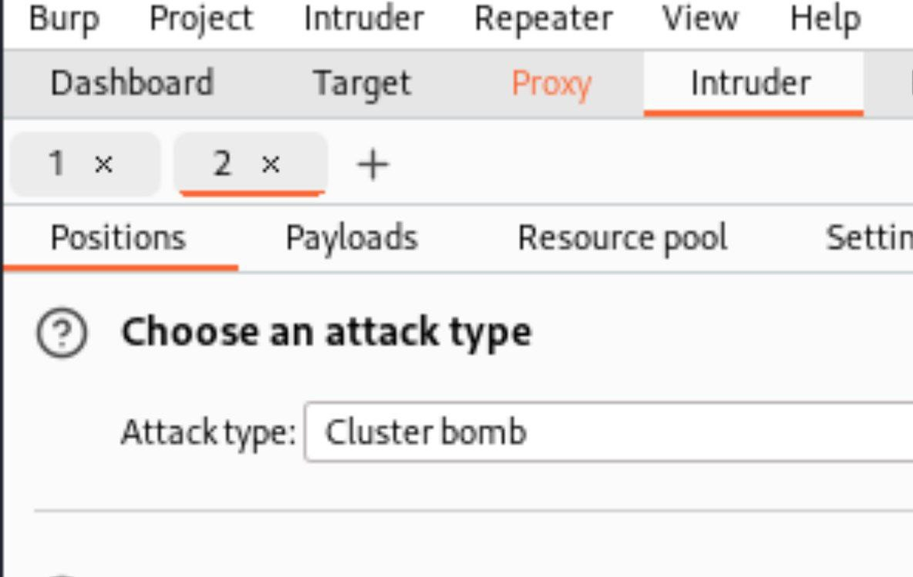

Тип атака

## Список 1

Отметила два параметра для подбора, поэтому создала два списка со значениями для подбора в payload:

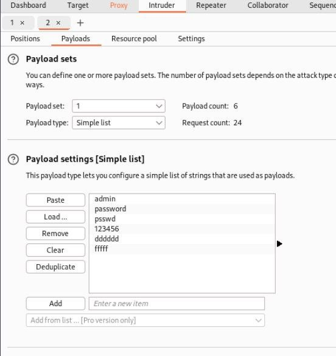

Список 1

## Список 2

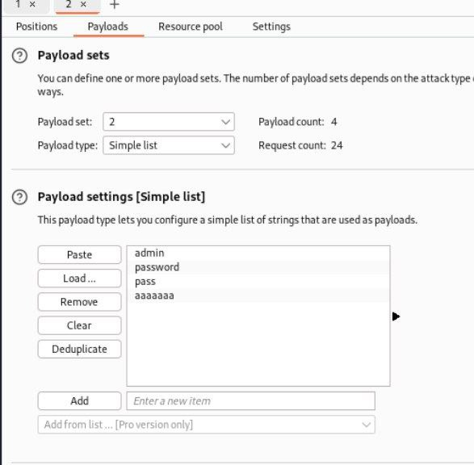

Список 2

## Правильная пара

Далее запускаю атаку и начинаю подбор. При открытии каждого post-запроса можно увидеть полученный get-запрос, в нем видно, куда нас перенаправило после выполнения ввода пары пользователь-пароль. В этом случае с подбором пары нас перенаправило на страницу index.php, значит пара должна быть верной:

[figure not shown]

Правильная пара

## Окна repeater и response

С использаванием repeater делаю доплнительную проверку. Нажимаю send и в response получаю результат перенаправление на index.php.

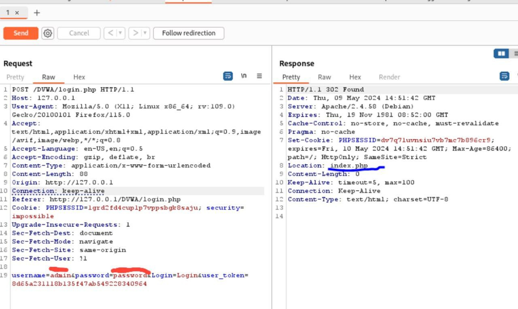

Окна repeater и response

## Полученная страница

В подокне Render получаю то, как выглядит полученная страница:

[figure not shown]

Полученная страница

# Выводы

Научилась использовать Burp Suite.